# EasyVisa Project - Ensemble Techniques

## **Building Bagging models (with hyperparameter tuning)**

```python
# Libraries to import decision tree classifier and different ensemble classifiers
from sklearn.ensemble import BaggingClassifier
from sklearn.ensemble import RandomForestClassifier
from sklearn.tree import DecisionTreeClassifier
from sklearn import tree

# Libraries to tune model, get different metric scores
from sklearn import metrics
from sklearn.metrics import confusion_matrix, accuracy_score, precision_score, recall_score,f1_score,roc_auc_score #classification_report
from sklearn.model_selection import GridSearchCV
```

### Starting with Decision Tree Classifier

```python
#Fitting the Decision Tree Classifier model
Visa_dtree = DecisionTreeClassifier(random_state=1)
Visa_dtree.fit(X_train,y_train)
```

```
DecisionTreeClassifier(random_state=1)
```

```python
#Calculating different metrics for training data
Visa_dtree_train_perf = model_performance_classification_sklearn(Visa_dtree,X_train,y_train)
print("Training performance:")
Visa_dtree_train_perf
```

```
Training performance:
```

|  | Accuracy | Recall | Precision | F1 |
| --- | --- | --- | --- | --- |
| 0 | 1.0 | 1.0 | 1.0 | 1.0 |

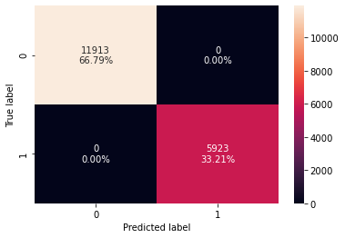

```python
#Creating confusion matrix for training data
confusion_matrix_sklearn(Visa_dtree,X_train,y_train)
```

#### Confusion Matrix -

- Visa denied and the model predicted it correctly that applicant will have visa denied: True Positive (observed=1,predicted=1)
- Visa certified and the model predicted it correctly that applicant will have visa denied: False Positive (observed=0,predicted=1)
- Visa certified and the model predicted it correctly that applicant will have visa certified: True Negative (observed=0,predicted=0)
- Visa denied and the model predicted it correctly that applicant will have visa certified: False Negative (observed=1,predicted=0)

```python
#Calculating different metrics for test data
Visa_dtree_test_perf = model_performance_classification_sklearn(Visa_dtree,X_test,y_test)
print("Testing performance:")
Visa_dtree_test_perf
```

```
Testing performance:
```

|  | Accuracy | Recall | Precision | F1 |
| --- | --- | --- | --- | --- |
| 0 | 0.667713 | 0.507286 | 0.499806 | 0.503518 |

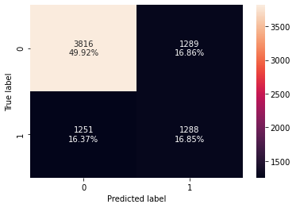

```python
#Creating confusion matrix
confusion_matrix_sklearn(Visa_dtree,X_test,y_test)
```

#### Observations:

- The Decision Tree model is overfitting as we can see the huge difference in performance metrics between training and testing regions.
- Out of the 2539 denied visa applications in testing dataset, the model was able to predict 1288 (around 50%) of them.
- Let's tune the Decision Tree model with hyperparameters.

### Hyperparameter Tuning on Decision Tree Classifier

```python
#Choose the type of classifier.
Visa_dtree_tuned = DecisionTreeClassifier(class_weight={0:0.332,1:0.668},random_state=1)

# Grid of parameters to choose from
parameters = {'max_depth': np.arange(2,30),
              'min_samples_leaf': [1, 2, 5, 7, 10],
              'max_leaf_nodes' : [2, 3, 5, 10,15],
              'min_impurity_decrease': [0.0001,0.001,0.01,0.1]
             }

# Type of scoring used to compare parameter combinations
scorer = metrics.make_scorer(metrics.recall_score)

# Run the grid search
grid_obj = GridSearchCV(Visa_dtree_tuned, parameters, scoring=scorer,n_jobs=-1)
grid_obj = grid_obj.fit(X_train, y_train)
```

```python
# Set the clf to the best combination of parameters
Visa_dtree_tuned = grid_obj.best_estimator_

# Fit the best algorithm to the data.
Visa_dtree_tuned.fit(X_train, y_train)
```

```
DecisionTreeClassifier(class_weight={0: 0.332, 1: 0.668}, max_depth=2,
                       max_leaf_nodes=2, min_impurity_decrease=0.1,
                       random_state=1)
```

```python
#Calculating different metrics for training data
Visa_dtree_tuned_train_perf = model_performance_classification_sklearn(Visa_dtree_tuned,X_train,y_train)
print("Training performance:")
Visa_dtree_tuned_train_perf
```

```
Training performance:
```

|  | Accuracy | Recall | Precision | F1 |
| --- | --- | --- | --- | --- |
| 0 | 0.332081 | 1.0 | 0.332081 | 0.49859 |

```python
#Calculating different metrics for test data
Visa_dtree_tuned_test_perf = model_performance_classification_sklearn(Visa_dtree_tuned,X_test,y_test)
print("Testing performance:")
Visa_dtree_tuned_test_perf
```

```
Testing performance:
```

|  | Accuracy | Recall | Precision | F1 |
| --- | --- | --- | --- | --- |
| 0 | 0.332156 | 1.0 | 0.332156 | 0.498674 |

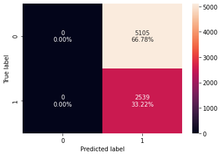

```python
#Creating confusion matrix
confusion_matrix_sklearn(Visa_dtree_tuned,X_test,y_test)
```

#### Observations:

- The Decision Tree Hyperparameter tuned model is not overfitting as performance metrics between training and testing regions are very similar.
- Out of the 2539 denied visa applications in testing dataset, the model was able to predict all of them.
- This model is always predicting the case as **denied** and as expected, accuracy/precision metric of this model is not acceptable.

### Random Forest Classifier

```python
#Fitting the random forest model
Visa_rf_estimator = RandomForestClassifier(random_state=1)
Visa_rf_estimator.fit(X_train,y_train)
```

```
RandomForestClassifier(random_state=1)
```

```python
#Calculating different metrics for training data
Visa_rf_train_perf = model_performance_classification_sklearn(Visa_rf_estimator,X_train,y_train)
print("Training performance:")
Visa_rf_train_perf
```

```
Training performance:
```

|  | Accuracy | Recall | Precision | F1 |
| --- | --- | --- | --- | --- |
| 0 | 1.0 | 1.0 | 1.0 | 1.0 |

```python
#Calculating different metrics for test data
Visa_rf_test_perf = model_performance_classification_sklearn(Visa_rf_estimator,X_test,y_test)
print("Testing performance:")
Visa_rf_test_perf
```

```
Testing performance:
```

|  | Accuracy | Recall | Precision | F1 |
| --- | --- | --- | --- | --- |
| 0 | 0.735348 | 0.501378 | 0.627094 | 0.557234 |

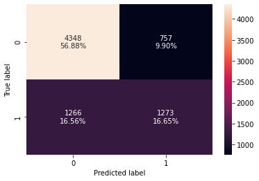

```python
#Creating confusion matrix
confusion_matrix_sklearn(Visa_rf_estimator,X_test,y_test)
```

#### Observations:

- The Random forest model is overfitting as we can see the huge difference in performance metrics between training and testing regions.
- Out of the 2539 denied visa applications in testing dataset, the model was able to predict 1273 (around 50%) of them.
- Let's tune the Random forest model with hyperparameters.

### Hyperparameter Tuning on Random Forest Classifier

```python
# Choose the type of classifier.
Visa_rf_tuned = RandomForestClassifier(class_weight={0:0.332,1:0.668},random_state=1,bootstrap=True)

parameters = {
                'max_depth': list(np.arange(5,30,5)) + [None],
                'max_features': ['sqrt','log2',None],
                'min_samples_leaf': np.arange(1,15,5),
                'min_samples_split': np.arange(2, 20, 5),
                'n_estimators': np.arange(10,110,10)}


# Type of scoring used to compare parameter combinations
scorer = metrics.make_scorer(metrics.recall_score)

# Run the grid search
grid_obj = GridSearchCV(Visa_rf_tuned, parameters, scoring=scorer, cv=5,n_jobs=-1)
grid_obj = grid_obj.fit(X_train, y_train)
```

```python
# Set the clf to the best combination of parameters
Visa_rf_tuned = grid_obj.best_estimator_

# Fit the best algorithm to the data.
Visa_rf_tuned.fit(X_train, y_train)
```

```
RandomForestClassifier(class_weight={0: 0.332, 1: 0.668}, max_depth=5,
                       max_features='sqrt', min_samples_leaf=6,
                       min_samples_split=17, n_estimators=20, random_state=1)
```

```python
#Calculating different metrics for training data
Visa_rf_tuned_train_perf = model_performance_classification_sklearn(Visa_rf_tuned,X_train,y_train)
print("Training performance:")
Visa_rf_tuned_train_perf
```

```
Training performance:
```

|  | Accuracy | Recall | Precision | F1 |
| --- | --- | --- | --- | --- |
| 0 | 0.689448 | 0.725139 | 0.523398 | 0.607969 |

```python
#Calculating different metrics for test data
Visa_rf_tuned_test_perf = model_performance_classification_sklearn(Visa_rf_tuned,X_test,y_test)
print("Testing performance:")
Visa_rf_tuned_test_perf
```

```
Testing performance:
```

|  | Accuracy | Recall | Precision | F1 |
| --- | --- | --- | --- | --- |
| 0 | 0.693616 | 0.727846 | 0.528151 | 0.612123 |

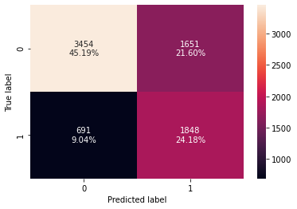

```python
#Creating confusion matrix
confusion_matrix_sklearn(Visa_rf_tuned,X_test,y_test)
```

#### Observations:

- The Random forest hyperparameter tuned model is not overfitting as the performance metrics between training and testing regions are in close range .
- Out of the 2539 denied visa applications in testing dataset, the model was able to predict 1848 (around 72%) of them.
- This model looks promising, it had good recall. But let's explore a model with bagging classifier.

### Bagging Classifier

```python
#Fitting the model
Visa_bagging_classifier = BaggingClassifier(random_state=1)
Visa_bagging_classifier.fit(X_train,y_train)
```

```
BaggingClassifier(random_state=1)
```

```python
#Calculating different metrics for training data
Visa_bagging_classifier_train_perf = model_performance_classification_sklearn(Visa_bagging_classifier,X_train,y_train)
print("Training performance:")
Visa_bagging_classifier_train_perf
```

```
Training performance:
```

|  | Accuracy | Recall | Precision | F1 |
| --- | --- | --- | --- | --- |
| 0 | 0.977349 | 0.939726 | 0.991627 | 0.964979 |

```python
#Calculating different metrics for test data
Visa_bagging_classifier_test_perf = model_performance_classification_sklearn(Visa_bagging_classifier,X_test,y_test)
print("Testing performance:")
Visa_bagging_classifier_test_perf
```

```
Testing performance:
```

|  | Accuracy | Recall | Precision | F1 |
| --- | --- | --- | --- | --- |
| 0 | 0.710754 | 0.435998 | 0.586957 | 0.500339 |

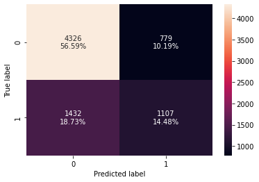

```python
#Creating confusion matrix
confusion_matrix_sklearn(Visa_bagging_classifier,X_test,y_test)
```

#### Observations:

- The Bagging classifier model is overfitting as we can see the huge difference in performance metrics between training and testing regions.
- Out of the 2539 denied visa applications in testing dataset, the model was able to predict 1107 (around 44%) of them.
- Let's tune the Bagging classifier model with hyperparameters and see if we can improve the recall.

### Hyperparameter Tuning for Bagging Classifier

```python
# Choose the type of classifier.
Visa_bagging_tuned = BaggingClassifier(random_state=1)

# Grid of parameters to choose from
parameters = {'max_samples': [0.7,0.8,0.9,1],
              'max_features': [0.7,0.8,0.9,1],
              'n_estimators' : [10,20,30,40,50],
             }

# Type of scoring used to compare parameter combinations
scorer = metrics.make_scorer(metrics.recall_score)

# Run the grid search
grid_obj = GridSearchCV(Visa_bagging_tuned, parameters, scoring=scorer,cv=5)
grid_obj = grid_obj.fit(X_train, y_train)
```

```python
# Set the clf to the best combination of parameters
Visa_bagging_tuned = grid_obj.best_estimator_

# Fit the best algorithm to the data.
Visa_bagging_tuned.fit(X_train, y_train)
```

```
BaggingClassifier(max_features=0.9, max_samples=0.9, n_estimators=50,
                  random_state=1)
```

```python
#Calculating different metrics for training data
Visa_bagging_tuned_train_perf = model_performance_classification_sklearn(Visa_bagging_tuned,X_train,y_train)
print("Training performance:")
Visa_bagging_tuned_train_perf
```

```
Training performance:
```

|  | Accuracy | Recall | Precision | F1 |
| --- | --- | --- | --- | --- |
| 0 | 0.998879 | 0.996961 | 0.999661 | 0.998309 |

```python
#Calculating different metrics for test data
Visa_bagging_tuned_test_perf = model_performance_classification_sklearn(Visa_bagging_tuned,X_test,y_test)
print("Testing performance:")
Visa_bagging_tuned_test_perf
```

```
Testing performance:
```

|  | Accuracy | Recall | Precision | F1 |
| --- | --- | --- | --- | --- |
| 0 | 0.730638 | 0.471839 | 0.625261 | 0.537823 |

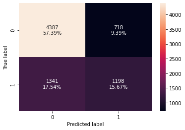

```python
#Creating confusion matrix
confusion_matrix_sklearn(Visa_bagging_tuned,X_test,y_test)
```

#### Observations:

- The Bagging classifier hyperparameter tuned model is overfitting as we can see the huge difference in performance metrics between training and testing regions.
- Out of the 2539 denied visa applications in testing dataset, the model was able to predict 1198 (around 47%) of them.
- The recall has for Bagging classifier model had improved with hyperparameter tuning. But we should keep exploring other models.

## **Building Boosting models (with hyperparameter tuning)**

```python
# Libraries to import different boosting classifiers
from sklearn.ensemble import AdaBoostClassifier, GradientBoostingClassifier
from xgboost import XGBClassifier
from sklearn.ensemble import StackingClassifier
```

### AdaBoost Classifier

```python
#Fitting the AdaBoost Classifier model
Visa_ab_classifier = AdaBoostClassifier(random_state=1)
Visa_ab_classifier.fit(X_train,y_train)
```

```
AdaBoostClassifier(random_state=1)
```

```python
#Calculating different metrics for training data
Visa_ab_classifier_train_perf = model_performance_classification_sklearn(Visa_ab_classifier,X_train,y_train)
print("Training performance:")
Visa_ab_classifier_train_perf
```

```
Training performance:
```

|  | Accuracy | Recall | Precision | F1 |
| --- | --- | --- | --- | --- |
| 0 | 0.73688 | 0.438291 | 0.655225 | 0.52524 |

```python
#Calculating different metrics for test data
Visa_ab_classifier_test_perf = model_performance_classification_sklearn(Visa_ab_classifier,X_test,y_test)
print("Testing performance:")
Visa_ab_classifier_test_perf
```

```
Testing performance:
```

|  | Accuracy | Recall | Precision | F1 |
| --- | --- | --- | --- | --- |
| 0 | 0.732601 | 0.422213 | 0.650091 | 0.511939 |

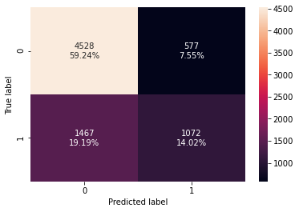

```python
#Creating confusion matrix
confusion_matrix_sklearn(Visa_ab_classifier,X_test,y_test)
```

#### Observations:

- The Adaboost classifier model is not overfitting the performance metrics between training and testing regions are not far from each other.
- Out of the 2539 denied visa applications in testing dataset, the model was able to predict 1072 (around 42%) of them.
- Let's tune the Adaboost classifier model with hyperparameters and see if we can improve the recall.

### Hyperparameter Tuning for AdaBoost Classifier model

```python
# Choose the type of classifier.
Visa_abc_tuned = AdaBoostClassifier(random_state=1)

# Grid of parameters to choose from
parameters = {
    #Let's try different max_depth for base_estimator
    "base_estimator":[DecisionTreeClassifier(max_depth=1),DecisionTreeClassifier(max_depth=2),
                      DecisionTreeClassifier(max_depth=3)],
    "n_estimators": np.arange(10,110,10),
    "learning_rate":np.arange(0.1,2,0.1)
}

# Type of scoring used to compare parameter  combinations
scorer = metrics.make_scorer(metrics.recall_score)

# Run the grid search
grid_obj = GridSearchCV(Visa_abc_tuned, parameters, scoring=scorer,cv=5)
grid_obj = grid_obj.fit(X_train, y_train)
```

```python
# Set the clf to the best combination of parameters
Visa_abc_tuned = grid_obj.best_estimator_

# Fit the best algorithm to the data.
Visa_abc_tuned.fit(X_train, y_train)
```

```
AdaBoostClassifier(base_estimator=DecisionTreeClassifier(max_depth=3),
                   learning_rate=1.8000000000000003, n_estimators=10,
                   random_state=1)
```

```python
#Calculating different metrics for training data
Visa_abc_tuned_train_perf = model_performance_classification_sklearn(Visa_abc_tuned,X_train,y_train)
print("Training performance:")
Visa_abc_tuned_train_perf
```

```
Training performance:
```

|  | Accuracy | Recall | Precision | F1 |
| --- | --- | --- | --- | --- |
| 0 | 0.731274 | 0.459058 | 0.631151 | 0.531522 |

```python
#Calculating different metrics for test data
Visa_abc_tuned_test_perf = model_performance_classification_sklearn(Visa_abc_tuned,X_test,y_test)
print("Testing performance:")
Visa_abc_tuned_test_perf
```

```
Testing performance:
```

|  | Accuracy | Recall | Precision | F1 |
| --- | --- | --- | --- | --- |
| 0 | 0.72776 | 0.45963 | 0.622068 | 0.528652 |

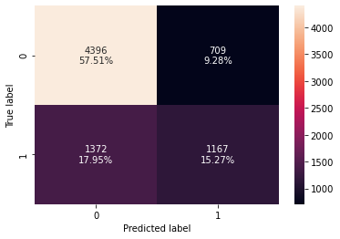

```python
#Creating confusion matrix
confusion_matrix_sklearn(Visa_abc_tuned,X_test,y_test)
```

### Gradient Boosting Classifier

```python
#Fitting the Gradient Boosting Classifier model
Visa_gb_classifier = GradientBoostingClassifier(random_state=1)
Visa_gb_classifier.fit(X_train,y_train)
```

```
GradientBoostingClassifier(random_state=1)
```

```python
#Calculating different metrics for training data
Visa_gb_classifier_train_perf = model_performance_classification_sklearn(Visa_gb_classifier,X_train,y_train)
print("Training performance:")
Visa_gb_classifier_train_perf
```

```
Training performance:
```

|  | Accuracy | Recall | Precision | F1 |
| --- | --- | --- | --- | --- |
| 0 | 0.755158 | 0.501097 | 0.677626 | 0.576143 |

```python
#Calculating different metrics for test data
Visa_gb_classifier_test_perf = model_performance_classification_sklearn(Visa_gb_classifier,X_test,y_test)
print("Testing performance:")
Visa_gb_classifier_test_perf
```

```
Testing performance:
```

|  | Accuracy | Recall | Precision | F1 |
| --- | --- | --- | --- | --- |
| 0 | 0.753271 | 0.499015 | 0.673578 | 0.573303 |

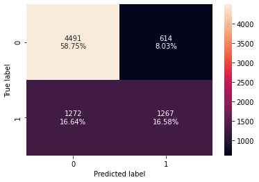

```python
#Creating confusion matrix
confusion_matrix_sklearn(Visa_gb_classifier,X_test,y_test)
```

#### Observations:

- The Gradient boost classifier model is not overfitting as the performance metrics between training and testing regions are in close range.
- Out of the 2539 denied visa applications in testing dataset, the model was able to predict 1267 (around 50%) of them.
- Let's try to imporve the Gradient boost classifier with hyperparameter tuning and see if we can get a better recall.

### Hyperparameter Tuning for Gradient Boosting Classifier

```python
# Choose the type of classifier.
Visa_gbc_tuned = GradientBoostingClassifier(init=AdaBoostClassifier(random_state=1),random_state=1)

# Grid of parameters to choose from
parameters = {
    "n_estimators": [100,150,200,250],
    "subsample":[0.8,0.9,1],
    "max_features":[0.7,0.8,0.9,1]
}

# Type of scoring used to compare parameter combinations
scorer = metrics.make_scorer(metrics.recall_score)

# Run the grid search
grid_obj = GridSearchCV(Visa_gbc_tuned, parameters, scoring=scorer,cv=5)
grid_obj = grid_obj.fit(X_train, y_train)
```

```python
# Set the clf to the best combination of parameters
Visa_gbc_tuned = grid_obj.best_estimator_

# Fit the best algorithm to the data.
Visa_gbc_tuned.fit(X_train, y_train)
```

```
GradientBoostingClassifier(init=AdaBoostClassifier(random_state=1),
                           max_features=0.9, random_state=1, subsample=0.9)
```

```python
#Calculating different metrics for training data
Visa_gbc_tuned_train_perf = model_performance_classification_sklearn(Visa_gbc_tuned,X_train,y_train)
print("Training performance:")
Visa_gbc_tuned_train_perf
```

```
Training performance:
```

|  | Accuracy | Recall | Precision | F1 |
| --- | --- | --- | --- | --- |
| 0 | 0.755775 | 0.510214 | 0.675006 | 0.581154 |

```python
#Calculating different metrics for test data
Visa_gbc_tuned_test_perf = model_performance_classification_sklearn(Visa_gbc_tuned,X_test,y_test)
print("Testing performance:")
Visa_gbc_tuned_test_perf
```

```
Testing performance:
```

|  | Accuracy | Recall | Precision | F1 |
| --- | --- | --- | --- | --- |
| 0 | 0.753009 | 0.505317 | 0.669974 | 0.576111 |

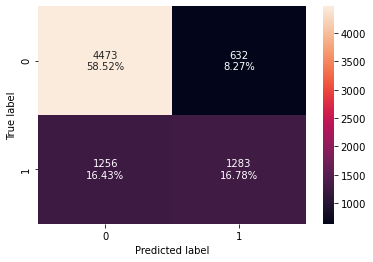

```python
#Creating confusion matrix
confusion_matrix_sklearn(Visa_gbc_tuned,X_test,y_test)
```

#### Observations:

- The Gradient boost classifier hyperparameter tuned model is not overfitting as the performance metrics between training and testing regions are in close range.
- Out of the 2539 denied visa applications in testing dataset, the model was able to predict 1283 (around 51%) of them.
- Let's try the XGBoost classifier and see if we can get a better recall.

### XGBoost Classifier

```python
#Fitting the XGBoost Classifier model
Visa_xgb_classifier = XGBClassifier(random_state=1, eval_metric='logloss')
Visa_xgb_classifier.fit(X_train,y_train)
```

```
XGBClassifier(base_score=0.5, booster='gbtree', colsample_bylevel=1,
              colsample_bynode=1, colsample_bytree=1, enable_categorical=False,
              eval_metric='logloss', gamma=0, gpu_id=-1, importance_type=None,
              interaction_constraints='', learning_rate=0.300000012,
              max_delta_step=0, max_depth=6, min_child_weight=1, missing=nan,
              monotone_constraints='()', n_estimators=100, n_jobs=4,
              num_parallel_tree=1, predictor='auto', random_state=1,
              reg_alpha=0, reg_lambda=1, scale_pos_weight=1, subsample=1,
              tree_method='exact', validate_parameters=1, verbosity=None)
```

```python
#Calculating different metrics for training data
Visa_xgb_classifier_train_perf = model_performance_classification_sklearn(Visa_xgb_classifier,X_train,y_train)
print("Training performance:")
Visa_xgb_classifier_train_perf
```

```
Training performance:
```

|  | Accuracy | Recall | Precision | F1 |
| --- | --- | --- | --- | --- |
| 0 | 0.837912 | 0.645619 | 0.828423 | 0.725686 |

```python
#Calculating different metrics for test data
Visa_xgb_classifier_test_perf = model_performance_classification_sklearn(Visa_xgb_classifier,X_test,y_test)
print("Testing performance:")
Visa_xgb_classifier_test_perf
```

```
Testing performance:
```

|  | Accuracy | Recall | Precision | F1 |
| --- | --- | --- | --- | --- |
| 0 | 0.736787 | 0.480898 | 0.637598 | 0.548271 |

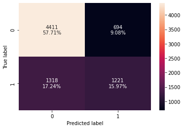

```python
#Creating confusion matrix
confusion_matrix_sklearn(Visa_xgb_classifier,X_test,y_test)
```

#### Observations:

- The XGBoost classifier model is can be considered as slightly overfitting as the accuracy metrics between training and testing regions have a difference of 10%.
- Out of the 2539 denied visa applications in testing dataset, the model was able to predict 1221 (around 48%) of them.
- Let's try the XGBoost classifier with hyperparameter tuning and see if we can get a better recall.

### Hyperparameter Tuning for XGBoost Classifier

```python
# Choose the type of classifier.
Visa_xgb_tuned = XGBClassifier(random_state=1, eval_metric='logloss')

# Grid of parameters to choose from
parameters = {
    "n_estimators": [10,30,50],
    "scale_pos_weight":[1,2,5],
    "subsample":[0.7,0.9,1],
    "learning_rate":[0.05, 0.1,0.2],
    "colsample_bytree":[0.7,0.9,1],
    "colsample_bylevel":[0.5,0.7,1]
}

# Type of scoring used to compare parameter combinations
scorer = metrics.make_scorer(metrics.recall_score)

# Run the grid search
grid_obj = GridSearchCV(Visa_xgb_tuned, parameters,scoring=scorer,cv=5)
grid_obj = grid_obj.fit(X_train, y_train)
```

```python
# Set the clf to the best combination of parameters
Visa_xgb_tuned = grid_obj.best_estimator_

# Fit the best algorithm to the data.
Visa_xgb_tuned.fit(X_train, y_train)
```

```
XGBClassifier(base_score=0.5, booster='gbtree', colsample_bylevel=1,
              colsample_bynode=1, colsample_bytree=0.7,
              enable_categorical=False, eval_metric='logloss', gamma=0,
              gpu_id=-1, importance_type=None, interaction_constraints='',
              learning_rate=0.05, max_delta_step=0, max_depth=6,
              min_child_weight=1, missing=nan, monotone_constraints='()',
              n_estimators=10, n_jobs=4, num_parallel_tree=1, predictor='auto',
              random_state=1, reg_alpha=0, reg_lambda=1, scale_pos_weight=5,
              subsample=0.7, tree_method='exact', validate_parameters=1,
              verbosity=None)
```

```python
#Calculating different metrics for training data
Visa_xgb_tuned_train_perf = model_performance_classification_sklearn(Visa_xgb_tuned,X_train,y_train)
print("Training performance:")
Visa_xgb_tuned_train_perf
```

```
Training performance:
```

|  | Accuracy | Recall | Precision | F1 |
| --- | --- | --- | --- | --- |
| 0 | 0.553599 | 0.939895 | 0.422607 | 0.583054 |

```python
#Calculating different metrics for test data
Visa_xgb_tuned_test_perf = model_performance_classification_sklearn(Visa_xgb_tuned,X_test,y_test)
print("Testing performance:")
Visa_xgb_tuned_test_perf
```

```
Testing performance:
```

|  | Accuracy | Recall | Precision | F1 |
| --- | --- | --- | --- | --- |
| 0 | 0.550759 | 0.936983 | 0.420838 | 0.580811 |

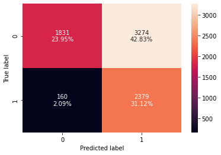

```python
#Creating confusion matrix
confusion_matrix_sklearn(Visa_xgb_tuned,X_test,y_test)
```

#### Observations:

- The XGBoost classifier hyperparameter tuned model is can be considered as not overfitting as the performance metrics between training and testing regions is not far apart.
- Out of the 2539 denied visa applications in testing dataset, the model was able to predict 2379 (around 93.7%) of them.
- This is an excellent model for recall, but the accuracy is only 55% and Precision is 42%. And the high recall comes at a cost, this model can predict only 1831 of the 5105 certified cases (35%).
- Let's try the Stacking classifier with hyperparameter tuning and see if we can get a better recall.

### Stacking Classifier

#### Now, let's build a stacking model with the tuned models - decision tree, random forest, and gradient boosting, then use XGBoost to get the final prediction.

```python
# Set the estimators and final_estimator for stacking classifier
estimators = [('Random Forest',Visa_rf_tuned),
              ('Gradient Boosting',Visa_gbc_tuned),
              ('Decision Tree',Visa_dtree_tuned)]
final_estimator = Visa_xgb_tuned
```

```python
#Fitting the Stacking Classifier model
Visa_stacking_classifier = StackingClassifier(estimators=estimators,final_estimator=final_estimator)
Visa_stacking_classifier.fit(X_train,y_train)
```

```
StackingClassifier(estimators=[('Random Forest',
                                RandomForestClassifier(class_weight={0: 0.332,
                                                                     1: 0.668},
                                                       max_depth=5,
                                                       max_features='sqrt',
                                                       min_samples_leaf=6,
                                                       min_samples_split=17,
                                                       n_estimators=20,
                                                       random_state=1)),
                               ('Gradient Boosting',
                                GradientBoostingClassifier(init=AdaBoostClassifier(random_state=1),
                                                           max_features=0.9,
                                                           random_state=1,
                                                           subsample=0.9)),
                               ('Decisio...
                                                 gpu_id=-1,
                                                 importance_type=None,
                                                 interaction_constraints='',
                                                 learning_rate=0.05,
                                                 max_delta_step=0, max_depth=6,
                                                 min_child_weight=1,
                                                 missing=nan,
                                                 monotone_constraints='()',
                                                 n_estimators=10, n_jobs=4,
                                                 num_parallel_tree=1,
                                                 predictor='auto',
                                                 random_state=1, reg_alpha=0,
                                                 reg_lambda=1,
                                                 scale_pos_weight=5,
                                                 subsample=0.7,
                                                 tree_method='exact',
                                                 validate_parameters=1,
                                                 verbosity=None))
```

```python
#Calculating different metrics for training data
Visa_stacking_classifier_train_perf = model_performance_classification_sklearn(Visa_stacking_classifier,X_train,y_train)
print("Training performance:")
Visa_stacking_classifier_train_perf
```

```
Training performance:
```

|  | Accuracy | Recall | Precision | F1 |
| --- | --- | --- | --- | --- |
| 0 | 0.53549 | 0.944623 | 0.412854 | 0.574583 |

```python
#Calculating different metrics for test data
Visa_stacking_classifier_test_perf = model_performance_classification_sklearn(Visa_stacking_classifier,X_test,y_test)
print("Testing performance:")
Visa_stacking_classifier_test_perf
```

```
Testing performance:
```

|  | Accuracy | Recall | Precision | F1 |
| --- | --- | --- | --- | --- |
| 0 | 0.537546 | 0.946042 | 0.414138 | 0.576088 |

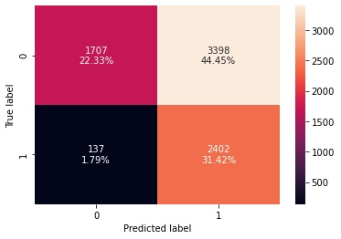

```python
#Creating confusion matrix
confusion_matrix_sklearn(Visa_stacking_classifier,X_test,y_test)
```

#### Observations:

- The Stacking classifier model is can be considered as not overfitting as the performance metrics between training and testing regions are in close range.
- Out of the 2539 denied visa applications in testing dataset, the model was able to predict 2402 (around 94.6%) of them.
- This is an excellent model for recall, but the accuracy is only 53% and Precision is 41%. And the high recall comes at a cost, this model can predict only 1707 of the 5105 certified cases (33%).

## **Bagging and Boosting models - Performance Summary - Train and Test**

### Model Performance Summary - Training set

```python
# training performance comparison
Visa_Bagging_Boosting_train_compare_df = pd.concat(
    [
        Visa_dtree_train_perf.T,
        Visa_dtree_tuned_train_perf.T,
        Visa_rf_train_perf.T,
        Visa_rf_tuned_train_perf.T,
        Visa_bagging_classifier_train_perf.T,
        Visa_bagging_tuned_train_perf.T,
        Visa_ab_classifier_train_perf.T,
        Visa_abc_tuned_train_perf.T,
        Visa_gb_classifier_train_perf.T,
        Visa_gbc_tuned_train_perf.T,
        Visa_xgb_classifier_train_perf.T,
        Visa_xgb_tuned_train_perf.T,
        Visa_stacking_classifier_train_perf.T,
    ],axis=1
)
Visa_Bagging_Boosting_train_compare_df.columns=[
    "Decision Tree",
    "Decision Tree Tuned",
    "Random Forest",
    "Random Forest Tuned",
    "Bagging Classifier",
    "Bagging Classifier Tuned",
    "AdaBoost Classifier",
    "AdaBoost Classifier Tuned",
    "Gradient Boost Classifier",
    "Gradient Boost Classifier Tuned",
    "XG Boost Classifier",
    "XG Boost Classifier Tuned",
    "Stacking Classifier"
]
print("Training performance comparison:")
Visa_Bagging_Boosting_train_compare_df
```

```
Training performance comparison:
```

|  | Decision Tree | Decision Tree Tuned | Random Forest | Random Forest Tuned | Bagging Classifier | Bagging Classifier Tuned | AdaBoost Classifier | AdaBoost Classifier Tuned | Gradient Boost Classifier | Gradient Boost Classifier Tuned | XG Boost Classifier | XG Boost Classifier Tuned | Stacking Classifier |
| --- | --- | --- | --- | --- | --- | --- | --- | --- | --- | --- | --- | --- | --- |
| Accuracy | 1.0 | 0.332081 | 1.0 | 0.689448 | 0.977349 | 0.998879 | 0.736880 | 0.731274 | 0.755158 | 0.755775 | 0.837912 | 0.553599 | 0.535490 |
| Recall | 1.0 | 1.000000 | 1.0 | 0.725139 | 0.939726 | 0.996961 | 0.438291 | 0.459058 | 0.501097 | 0.510214 | 0.645619 | 0.939895 | 0.944623 |
| Precision | 1.0 | 0.332081 | 1.0 | 0.523398 | 0.991627 | 0.999661 | 0.655225 | 0.631151 | 0.677626 | 0.675006 | 0.828423 | 0.422607 | 0.412854 |
| F1 | 1.0 | 0.498590 | 1.0 | 0.607969 | 0.964979 | 0.998309 | 0.525240 | 0.531522 | 0.576143 | 0.581154 | 0.725686 | 0.583054 | 0.574583 |

### Model Performance Summary - Testing set

```python
# testing performance comparison
Visa_Bagging_Boosting_test_compare_df = pd.concat(
    [
        Visa_dtree_test_perf.T,
        Visa_dtree_tuned_test_perf.T,
        Visa_rf_test_perf.T,
        Visa_rf_tuned_test_perf.T,
        Visa_bagging_classifier_test_perf.T,
        Visa_bagging_tuned_test_perf.T,
        Visa_ab_classifier_test_perf.T,
        Visa_abc_tuned_test_perf.T,
        Visa_gb_classifier_test_perf.T,
        Visa_gbc_tuned_test_perf.T,
        Visa_xgb_classifier_test_perf.T,
        Visa_xgb_tuned_test_perf.T,
        Visa_stacking_classifier_test_perf.T,
    ],axis=1
)
Visa_Bagging_Boosting_test_compare_df.columns=[
    "Decision Tree",
    "Decision Tree Tuned",
    "Random Forest",
    "Random Forest Tuned",
    "Bagging Classifier",
    "Bagging Classifier Tuned",
    "AdaBoost Classifier",
    "AdaBoost Classifier Tuned",
    "Gradient Boost Classifier",
    "Gradient Boost Classifier Tuned",
    "XG Boost Classifier",
    "XG Boost Classifier Tuned",
    "Stacking Classifier"
]
print("testing performance comparison:")
Visa_Bagging_Boosting_test_compare_df
```

```
testing performance comparison:
```

|  | Decision Tree | Decision Tree Tuned | Random Forest | Random Forest Tuned | Bagging Classifier | Bagging Classifier Tuned | AdaBoost Classifier | AdaBoost Classifier Tuned | Gradient Boost Classifier | Gradient Boost Classifier Tuned | XG Boost Classifier | XG Boost Classifier Tuned | Stacking Classifier |
| --- | --- | --- | --- | --- | --- | --- | --- | --- | --- | --- | --- | --- | --- |
| Accuracy | 0.667713 | 0.332156 | 0.735348 | 0.693616 | 0.710754 | 0.730638 | 0.732601 | 0.727760 | 0.753271 | 0.753009 | 0.736787 | 0.550759 | 0.537546 |
| Recall | 0.507286 | 1.000000 | 0.501378 | 0.727846 | 0.435998 | 0.471839 | 0.422213 | 0.459630 | 0.499015 | 0.505317 | 0.480898 | 0.936983 | 0.946042 |
| Precision | 0.499806 | 0.332156 | 0.627094 | 0.528151 | 0.586957 | 0.625261 | 0.650091 | 0.622068 | 0.673578 | 0.669974 | 0.637598 | 0.420838 | 0.414138 |
| F1 | 0.503518 | 0.498674 | 0.557234 | 0.612123 | 0.500339 | 0.537823 | 0.511939 | 0.528652 | 0.573303 | 0.576111 | 0.548271 | 0.580811 | 0.576088 |

### Conclusion

Hence I am going forward with **XG Boost classifer hyperparameter tuned model** as the **best model**.

#### Feature importance of XG Boost Classifier Tuned

```python
# importance of features in the model sorted in descending order.
pd.DataFrame(
    Visa_xgb_tuned.feature_importances_,
    columns = ['Importance'],
    index = X_test.columns
).sort_values(
    by = 'Importance',
    ascending=False
)
```

|  | Importance |
| --- | --- |
| education_of_employee | 0.289595 |
| has_job_experience_Y | 0.170201 |
| has_job_exp_&_no_training_req | 0.162352 |
| continent_Europe | 0.053487 |
| unit_of_wage_Year | 0.052370 |
| continent_North America | 0.041610 |
| region_of_employment_Midwest | 0.032874 |
| region_of_employment_South | 0.030849 |
| region_of_employment_West | 0.030608 |
| full_time_position_Y | 0.029051 |
| requires_job_training_Y | 0.023030 |
| prevailing_wage | 0.018660 |
| region_of_employment_Northeast | 0.014863 |
| continent_South America | 0.012056 |
| continent_Asia | 0.010291 |
| no_of_employees | 0.006526 |
| yr_of_estab | 0.006358 |
| continent_Oceania | 0.006300 |
| unit_of_wage_Month | 0.005043 |
| unit_of_wage_Week | 0.003875 |

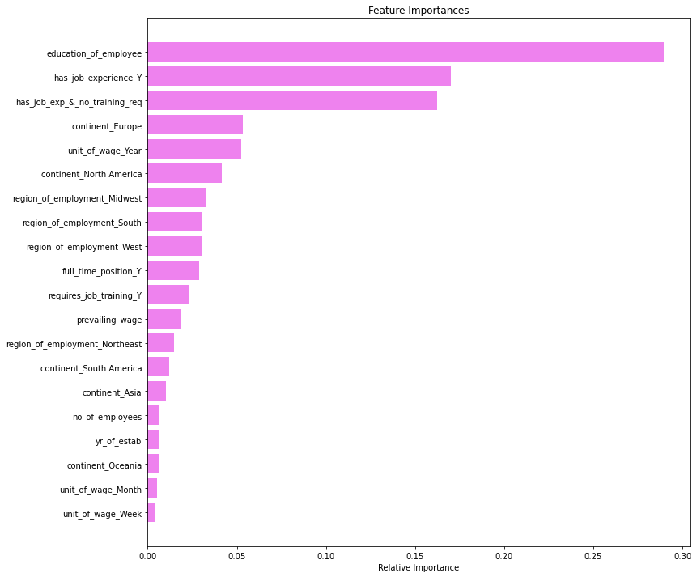

```python
# Get the list of feature names
feature_names = X_test.columns
# Get the importance of features
importances = Visa_xgb_tuned.feature_importances_
indices = np.argsort(importances)

# plotting the feature importance as a horizontal barchart.
plt.figure(figsize=(12,12))
plt.title('Feature Importances')
plt.barh(range(len(indices)), importances[indices], color='violet', align='center')
plt.yticks(range(len(indices)), [feature_names[i] for i in indices])
plt.xlabel('Relative Importance')
plt.show()
```

#### Observations:

- The three important features that impacts the visa status are *education_of_employee*, *has_job_experience* and the engineered feature *has_job*exp*&_no_training_req*.

## **Actionable Insights and Recommendations**

### Insights

1. Education of the employee is a major factor that influences the visa approval. Higher the education level, higher the chance of visa certification.
2. The job experience of the employee is the second major factor that impacts the visa approval. An employee with job experience has a better the chance of visa certification.
3. The job experience along with training of the employee is another factor that influences the visa approval of an employee. An employee with job experience who requires no additional training has a higher the chance of visa certification.
4. The continent of the employee is a factor that impacts the visa approval. Visa applications from Continent Europe has a better chance of getting certified.
5. Unit of wage also plays its part in visa approval for an employee. Employees with Unit of wage as Year has a higher chance of approval.

### Business Recommendations:

1. While EasyVisa would like every applicant to have the highest level of degree, job experience and training, that is not going to be the case. EasyVisa should act as an advocate for the applicants, highlighting the features that can lead to a successful visa certification and play down the weak features.
2. The challenge faced by EasyVisa is in processing the huge number of visa applications submitted by employers of their employees. EasyVisa should avoid the one-size-fits-all approach and segregate the applications first by education level, job experience and job training. As each of these application groups need to prioritize differently, EasyVisa should train their agents to handle each application group in its own way.
3. EasyVisa should highlight the education for master’s and Doctorate applicants. But for bachelor’s and High school level applicants, their job experience and training need to be highlighted.
4. EasyVisa should try to collect the visa applications as early as possible and review them to find the weak features of applicants. For example, if the applicant needs job training, he/she can join a training program before the application is submitted and show in the training progress in the visa application.
5. EasyVisa should investigate why the applicants from Europe has a higher chance of visa approval. For example, if it is due to English language training, EasyVisa can ask applicants from other continents to attend similar training and acquire an English language proficiency certificate.
6. EasyVisa should always submitting the unit of wage as year for each applicant. Submitting the prevailing wage as hourly, weekly, and monthly could lead to confusion and this can be avoided by following a standard approach.